# 905088050_stat102c_hw5

Violet Guo

12/4/2020

## Question1

## (a)

```r
tm <- rbind(c(0.5, 0.25, 0.25), c(0.5, 0, 0.5), c(0.25, 0.25, 0.5))
colnames(tm) <- c("Rainy", "Cloudy", "Sunny")
rownames(tm) <- c("Rainy", "Cloudy", "Sunny")
tm
```

```
##        Rainy Cloudy Sunny
## Rainy   0.50   0.25  0.25
## Cloudy  0.50   0.00  0.50
## Sunny   0.25   0.25  0.50
```

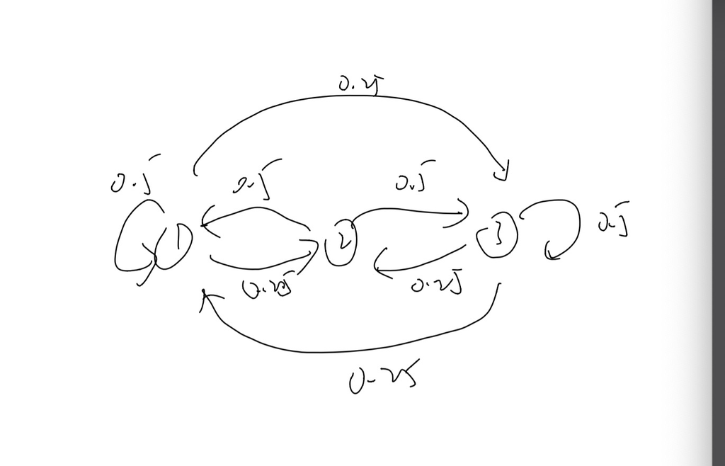

```r
knitr::include_graphics("q1(a).jpeg")
```

## (b)

We denote Sunny as S, Cloudy as C, Rainy as R. And suppose today is sunny, we have 0.25 probability that tomorrow is R, 0.25 that tomorrow is C, 0.5 that tomorrow is S. Then for rainy, we have 0.5 that 2 days from now is R, 0.25 that 2days from now is C, 0.25 that 2 days from now is S. For C, we have 0.5 probabiltiy that two days later is R, 0 that is C, 0.5 that is S. For S, we have 0.25 that is R, 0.25 that is C, 0.5 that is S. So for 2 days from now it is Rainy, we have SRR= 0.25*0.5=0.125. SCR = 0.25*0.5 = 0.125, SSR = 0.5*0.25=0.125. The total probability is 0.125*3=0.375. So for 2 days from now it is Cloudy, we have SRC = 0.25*0.25=0.0625, SCC = 0, SSC=0.5*0.25=0.125 The total probability is 0.0625+0.125=0.1875. So for 2 days from now it is Sunny, we have SRS = 0.25*025=0.0625, SCS = 0.25*0.5 = 0.125, SSS = 0.5*0.5=0.25 And the total probabiltiy is 0.0625+0.125+0.25= 0.4375.

## (c)

From the transition state diagram we could see that since all the states oculd communicate with each other, it is irreducible.

```r
tm1 <- tm
for (i in 1:999){
  tm <- tm1%*% tm
}
```

```r
tm
```

```
##        Rainy Cloudy Sunny
## Rainy    0.4    0.2   0.4
## Cloudy   0.4    0.2   0.4
## Sunny    0.4    0.2   0.4
```

$$\begin{aligned}
&\text {From above we know that}\pi_0 = 0.4, \pi_1 = 0.2, \pi_2 = 0.4\\
&\text {And the distribution of }\pi \text{ would obey therule that}\\
&\ \pi_j = \sum_{k=0}^{N}\pi_kP_{kj} \text{ for j = 0,1,...N and } \sum_{i=0}^{N}\pi_i = 1\\
&\text {we can see here} \pi_0 = 0.5*\pi_0 + 0.5*\pi_1 + 0.25*\pi_2\\
&\ \pi_1 = 0.25*\pi_0 + 0.25*\pi_2 \text{ and } \pi_3 = 0.25*\pi_0 + 0.5*\pi_1 + 0.5 * \pi_2 \\
&\text{and } \sum_{i=0}^{N}\pi = 0.4+0.4+0.2 = 1 \\
&\text{so this is a stationary distribution. }
\end{aligned}$$

## Quetsion2

$$\begin{aligned}
&\text{Assume }\alpha_i > 0 \text{for i = 1,..,6. Since P is regulard and must}\\
&\text{have positive entries, a limiting distribtion. }\\
&\ \pi = (\pi_0, ..., \pi_5) \text{exists and is the unique solution to the system of the questions}\\
&\ \pi_0 = \alpha_0\pi_0 + \pi_1, \pi_1 = \alpha_1\pi_0 + \pi_2,\\
&\ \pi_2 = \alpha_2\pi_0 + \pi_3,\pi_3 = \alpha_3\pi_0+\pi_4,\\
&\ \pi_4 =\alpha_4\pi_0+\pi_5, \pi_5=\alpha_5\pi_0\\
&\ \pi_0+\pi_1+\pi_2 + \pi_3 + \pi_4 + \pi_5 = 1\\
&\text{So we can get }\pi_0= \frac{1}{a_0+2a_1 + 3a_2 + 4a_3+5a_4+6a_5} \text{which is the limiting probability of being in state 0.}
\end{aligned}$$

## Question3

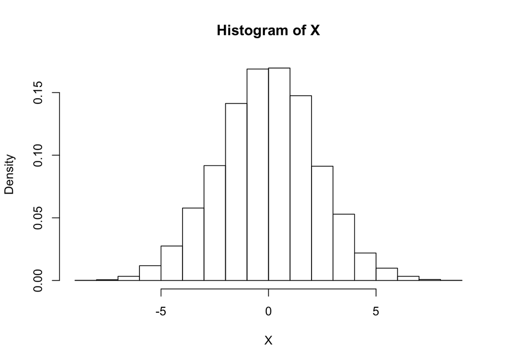

```r
set.seed(1000)
n <- 10000
alpha <- 0.9
x0 <- rnorm(1,0,1)
X <- c(x0)
for (i in 1:9999){
  x_new <- alpha*x0 + rnorm(1)
  error <- rnorm(1,0,1)
  x0 <- x_new
  X <- c(X, x_new)
}
hist(X,probability=T)
```

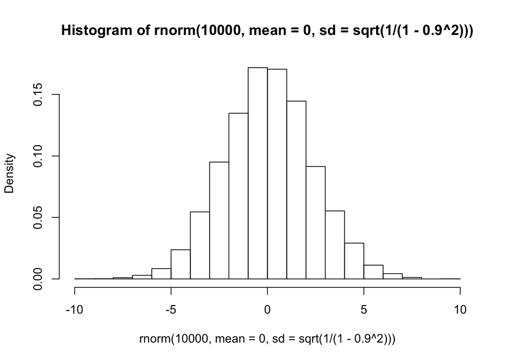

```r
hist(rnorm(10000, mean=0, sd=sqrt(1/(1-0.9^2))), probability=T)
```

```r
var(X)
```

```
## [1] 5.171397
```

```r
1/(1-0.9^2)
```

```
## [1] 5.263158
```

```r
mean(X)
```

```
## [1] -0.04024678
```

By checking the mean and varaince and histogram, we could see that my sample is pretty similar to N(0, 1/(1-alpha^2)).

## Question4

## (a)

$$\begin{aligned}
&\text{We know that }f(y|\lambda) = \frac{e^{-y}\lambda^y}{y!}\text{ and }\lambda \text{follows gamma distribution}\\
&\text {We would have the likelihood function} L(\lambda) = \prod_{n=1}^{n}f(y|\lambda) = \frac{e^{-n\lambda}\lambda^{\sum_1^n y_i}}{(y!)^n}\\
&\text{and }\pi(\lambda)=\frac{\beta^\alpha}{\Gamma(\alpha)}\lambda^{\alpha-1}e^{-\beta\lambda} \text{ so we would know that }\pi(\lambda|y) \propto \frac{\beta^\alpha}{\Gamma(\alpha)}\lambda^{\alpha-1}e^{-\beta\lambda} *\frac{e^{-n\lambda}\lambda^{\sum_1^n y_i}}{(y!)^n}\\
&\ = \frac{e^{-(\beta+n)\lambda}*\lambda^{\alpha+\sum_1^n y_i -1}*\beta^\alpha}{(y!)^n\Gamma(\alpha)}\\
&\text{From this formula above we could see that the core part of }Gamma(\alpha+\sum_{i=1}^{n}y_i, \beta+n) \\
&\ \text{are in the expression. So }\pi(\lambda|y) \text{~} Gamma(\alpha+\sum_{i=1}^{n}y_i, \beta+n)
\end{aligned}$$

## (b)

$$\begin{aligned}
&\text{We know that the mean of gamma distribution is }E(\lambda|y) = \frac{\alpha+\sum_{i=1}^{n}y_i}{\beta+n}\\
&\text{And we suppose }w = \frac{\beta}{\beta+n} \text{ we can get }E(\lambda|y) = \frac{\alpha}{\beta+n}*\frac{\beta}{\beta} + \frac{\sum y_i}{\beta+n}*\frac{n}{n}\\
&\ = \frac{\beta}{\beta+n}*\frac{\alpha}{\beta}+\bar y*\frac{n}{\beta+n}
\end{aligned}$$

## (c)

$$\begin{aligned}
&\text{As n goes to infinity, } \frac{n}{\beta+n} \text{becomes dominate so the} E(\lambda|y)\\
&\text{ will be close to } \bar y.
\end{aligned}$$

## (d)

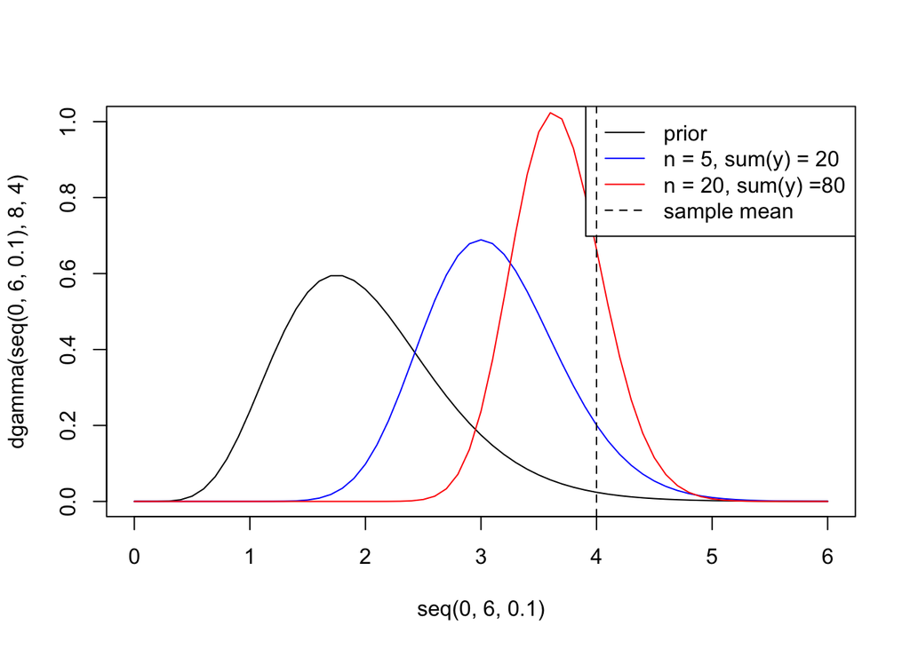

```r
plot(seq(0,6,0.1), dgamma(seq(0,6,0.1), 8,4), col=1, type = 'l', ylim = c(0,1))
lines(seq(0,6,0.1), dgamma(seq(0,6,0.1), 28,9), col="blue")
lines(seq(0,6,0.1), dgamma(seq(0,6,0.1), 88,24), col="red")
legend("topright",c("prior","n = 5, sum(y) = 20", "n = 20, sum(y) =80", "sample mean"), col = c("black","blue","red","black"), lty = c(1,1,1,2))
abline(v = 4, lty = 2)
```

## (e)

```r
qgamma(0.025,28,9)
```

```
## [1] 2.067311
```

```r
qgamma(1-0.025, 28, 9)
```

```
## [1] 4.364842
```

```r
qgamma(0.025,88,24)
```

```
## [1] 2.940774
```

```r
qgamma(1-0.025,88,24)
```

```
## [1] 4.471424
```

For (i), the 95% quantile-based credible interval is between 2.067311 and 4.364842. It could interpreted as the probability is 95% that this intervel will coever the true value of lambda after you observed Y=y.

For (ii), the 95% quantile-based credible interval is between 2.940774 and 4.471424. It could interpreted as the probability is 95% that the intervel will coever the true value of lambda after you observed Y=y.

## Question5

## (a)

$$\begin{aligned}
&\text{1. Our proposal distributio is }N(\mu, \sigma)\\
&\text{2. generate }X_0 \text{from the proposal distribution}\\
&\text{3. Repeat until the chain has converged to stationary distribution according to the criterion }\\
&\text{4.Generate Y from the proposal distribution }\\
&\text{5. Generate U from uniform(0,1)}\\
&\text{6. compute } r =\frac{f(Y)g(X_t|Y)}{f(X_t)g(Y|X+t)}\\
&\text{7. If U<r, accept Y and set }X_{t+1} \text{=Y; otherwise} X_{t+1} = X_t\\
&\text{8. increment t}
\end{aligned}$$
## (b)

```r
## suppose we use the N(0,1) as the proposal distribution
set.seed(9999)
n <- 9999
x <- rnorm(1,0,1)
for(t in 2:n){
  Y <- rnorm(1,0,1)
  r <- (dcauchy(Y,0,1)*dnorm(X[t-1]))/(dcauchy(X[t-1],0,1)*dnorm(Y,0,1))
  r <- min(1,r)
  U <- runif(1,0,1)
  if (U<r){
    X[t] <- Y
  }else{
    X[t] <- X[t-1]
  }
}
```

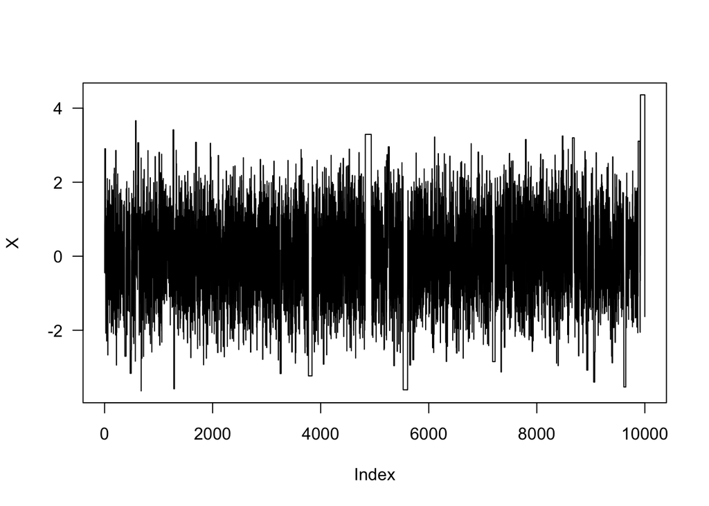

```r
plot(X, type="l", las=1)
```

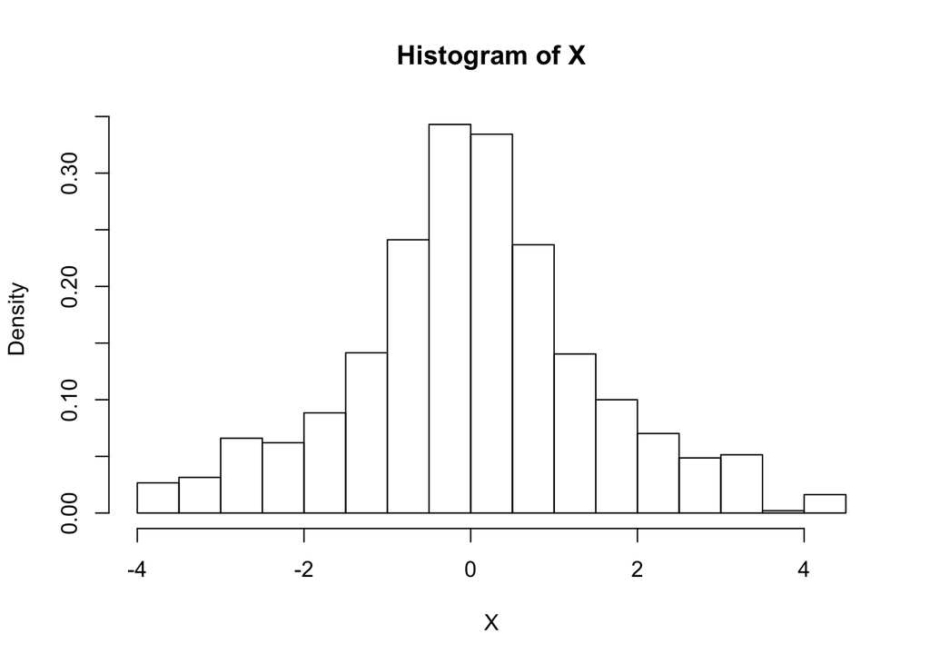

```r
hist(X, prob=T)
```

## (c)

```r
summary(X)
```

```
##      Min.   1st Qu.    Median      Mean   3rd Qu.      Max.
## -3.639106 -0.793429 -0.000023  0.016579  0.810835  4.360828
```

```r
qcauchy(0.25)
```

```
## [1] -1
```

```r
qcauchy(0.5)
```

```
## [1] 0
```

```r
qcauchy(0.75)
```

```
## [1] 1
```

My sample is pretty close to the output of qcauchy by checking the quantiles.

## Question6

## (a)

$$\begin{aligned}
&\text{We have success of 24*20+6+7+7+14+18=532 success in total}\\
&\text{ and 5 fails in total.This follows geometric distribuiton }\\
&\text{and the total number of trails is 537. }\\
&\text{To find the posterior distirbuiton }f(\mu | x) \text{let f(p) = }1/(1-0)=1\\
&\ f(x|p) ={n \choose x} p^x(1-p)^{n-x}\\
&\ f(x) = \int_0^1 {n \choose x} p^x(1-o)^{n-x} dp\\
&\ = {n \choose x} \int_0^1 p^x(1-o)^{n-x} dp \\
&\text{Let q = 1-p}\\
&\ f(x) ={n \choose x} \int_0^1 p^x(1-p)^{n-x} dp \\
&\ ={n \choose x} Beta(n-x+1, x+1)\\
&\ f(p|x) = \frac{f(x|p)f(p)}{f(x)}\\
&\ = \frac{{n \choose x} p^x(1-p)^{n-x} }{{n \choose x} Beta(n-x+1, x+1)}\\
&\ = \frac{p^x(1-p)^{n-x}}{Btea(n-x+1, x+1)}\\
&\ = \frac{p^532 (1-p)^5}{Beta(533,6)}\\
&\text {Since }\mu = \frac{p}{1-p}, p=\frac{\mu}{1+\mu}\\
&\ F_M(\mu)=P(\frac{p}{1-p} \leq \mu)=F_p(\frac{\mu}{1+\mu})\\
&\ f(\mu|x) =\frac{1}{(1+\mu)^2}\frac{(1/(1+\mu))^{532}(1-(1/(1+u)))^5}{Btea(533, 6)}\\
&\text{Algorithm: 1. choose Gamma as our proposal distrbution }g(.|X_t)\\
&\text{2.Generae }X_0 \text{from the proposal distribution }\\
&\text {3.Repeat until th chain has converged to stationary distribuiton according to some criterion}\\
&\text{4. Generate Y from proposal distribution}\\
&\text{5. Generate U from uniform(0,1)}\\
&\text{6. Compute} r=\frac{f(Y)g(X_t|Y)}{f(X_t)g(Y|X_t)}\\
&\text{7. if U<r, accept Y and set}X_{t+1}=Y, \text{otherwise, set }X_{t+1}=X_t\\
&\text {8.increment t. }
\end{aligned}$$

## (b)

```r
f.mu <- function(x){
  exp(lbeta(533,6)+532*log(x)-532*log(1+x)-7*log(1+x))
}
fr <- function(x,y){
  a <- 532*(log(y)-log(x))
  b <- 539*(log(1+x)-log(1+y))
  return(exp(a+b))
}
m <- 10000
x <- numeric(m)
a <- 5
x[1] <- rlnorm(1)
k <- 0
u <- runif(m)
for (i in 2:m){
  xt <- x[i-1]
  y <- rgamma(1, shape=a, rate=a/xt)
  r <- fr(xt, y)*dgamma(xt, shape=a, rate=a/y)/dgamma(y, shape=a, rate=a/xt)
  if(u[i] <=r){
    x[i] <- y
  }else {
    x[i] <- xt
    k <- k+1
  }
}
```

acf

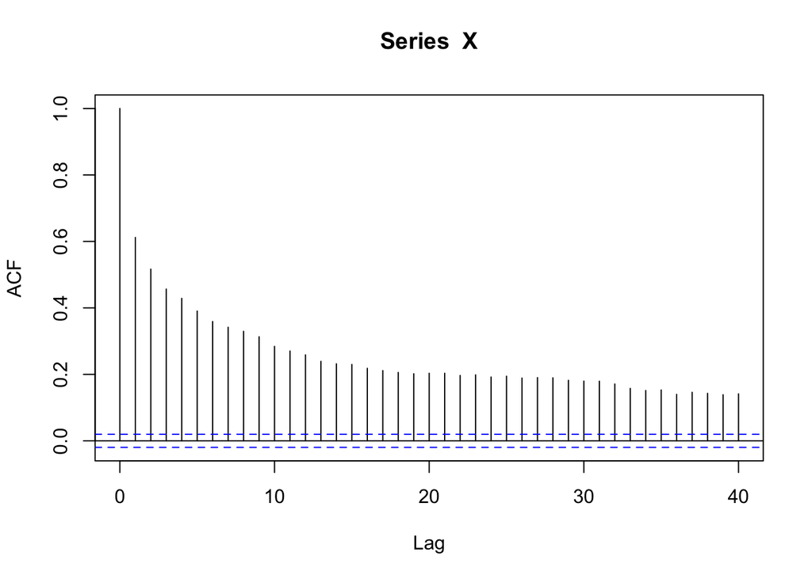

```r
acf(X)
```